```julia
using Plots
gr(size=(600,400))
default(fmt = :png)
```

# Regressão Linear, Polinomial e Múltipla

Conjunto de dados $\{(x^i, y^i), \ i = 1,\dots,m\}$, $x^i \in \mathbb{R}^p, y^i \in \mathbb{R}$.

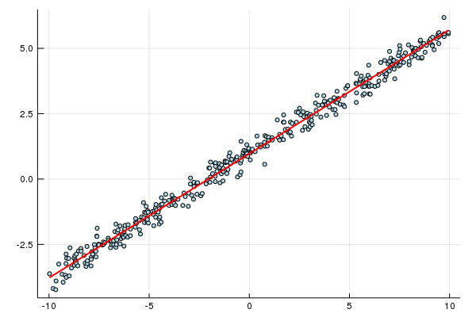

```julia
srand(0)
m = 400
x = sort(rand(m) * 20 - 10)
H = [x->1.0, x->x]
n = length(H)
θ = rand(n)
X = [H[j](x[i]) for i = 1:m, j = 1:n]
y = X * θ; y += randn(m) * 0.1 * std(y)
θ = (X' * X) \ (X' * y)
yhat = X * θ
scatter(x, y, ms=3, c=:lightblue, leg=false)
plot!(x, yhat, c=:red, lw=2)
```

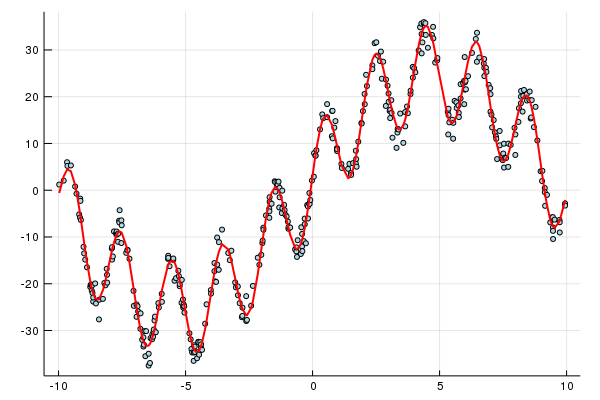

```julia
H = [x->x, x->sin(π * x), x->cos(π * x), x->sin(π * x / 10), x->cos(π * x / 10)]
n = length(H)
θ = [0.01; 10.0; 1.0; 25.0; 2.0]
X = [H[j](x[i]) for i = 1:m, j = 1:n]
y = X * θ; y += randn(m) * 0.1 * std(y)
θ = (X' * X) \ (X' * y)
yhat = X * θ
scatter(x, y, ms=3, c=:lightblue, leg=false)
plot!(x, yhat, c=:red, lw=2)
```

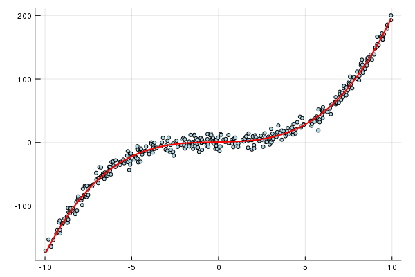

```julia
H = [x->1.0, x->x, x->x^2, x->x^3]
n = length(H)
θ = rand(n)
X = [H[j](x[i]) for i = 1:m, j = 1:n]
y = X * θ; y += randn(m) * 0.1 * std(y)
θ = (X' * X) \ (X' * y)
yhat = X * θ
scatter(x, y, ms=3, c=:lightblue, leg=false)
plot!(x, yhat, c=:red, lw=2)
```

## Modelo linear com perda quadrática - QUADRADOS MÍNIMOS

- $ h_{\theta}(x) = \theta_1 \phi_1(x) + \theta_2 \phi_2(x) + \dots + \theta_n \phi_n(x) = \theta^T\phi(x), $ cada $\phi_j:\mathbb{R}^p\to\mathbb{R}$, e $\phi:\mathbb{R}^p \to \mathbb{R}^n$.
- $\ell(\hat{y}, y) = \frac{1}{2}(\hat{y} - y)^2$.
- $$ \min L(\theta) = \frac{1}{2}\sum_{i=1}^m \big(\theta^T\phi(x^i) - y^i\big)^2. $$

Este problema em particular pode ser escrito como $$ \min L(\theta) = \frac{1}{2}\Vert X\theta - y\Vert^2, $$ onde $$ X = \left[\begin{array}{ccc} \phi_1(x^1) & \dots & \phi_n(x^1) \\ \phi_1(x^2) & \dots & \phi_n(x^2) \\ \vdots & & \vdots \\ \phi_1(x^m) & \dots & \phi_n(x^m) \end{array}\right]. $$

Esse problema é **convexo**, e se $X$ tem colunas linearmente independentes, é estritamente convexo, e tem solução única. As soluções do problema de minimização são soluções do sistema linear $$ X^TX \theta = X^Ty. $$

- Existem diversas maneiras de se resolver esse sistema. Se $X$ tem poucas colunas, podemos realmente montar o sistema e resolvê-lo.
- Podemos usar fatorações;
- Podemos usar o método dos gradientes conjugados.
- No problema de minimização, podemos utilizar métodos de otimização para funções quadráticas.
- Em particular, podemos usar o método de **gradiente estocástico**.

```julia
# Solução da sabatina AKA Cauchy para quadráticas
function cauchy(X, y; ϵ = 1e-6)
    m, n = size(X)
    θ = zeros(n)
    d = X' * y
    iter = 0
    while norm(d) > ϵ
        Xd = X * d
        α = dot(d, d) / dot(Xd, Xd)
        θ .+= α * d
        d = X' * (y - X * θ)
        iter += 1
    end
    return θ, norm(y - X * θ)^2, iter
end
```

```
cauchy (generic function with 1 method)
```

```
θ = [19.2331, 15.0885], res = 1945.9551278808003, R2 = 0.9832958683877462, iter = 9
```

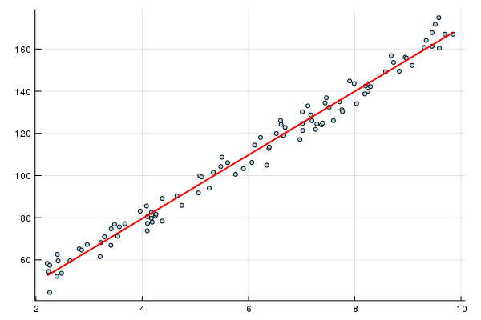

```julia
data = readcsv("dados.csv")
x = data[:, 1]
y = data[:, 2]
X = [ones(length(x)) x]
θ, res, iter = cauchy(X, y)
SStot = norm(y - mean(y))^2
println("θ = $θ, res = $res, R2 = $(1 - res/SStot), iter = $iter")
scatter(x, y, c=:lightblue, ms=3, leg=false)
plot!(x, X * θ, c=:red, lw=2)
```

- O problema $\min\ \frac{1}{2}\Vert X\beta - y\Vert^2$ pode ser resolvido de diversas outras maneiras:
  - Fatoração QR sobre $X$;
  - Gradientes conjugados;
  - Decomposição de Cholesky de $X^TX$;
  - Fatoração SVD.

# Regressão Não-Linear

- O modelo $h_{\theta}(x)$ não precisa ser linear;
- Se a perda é quadrática, temos quadrados mínimos não-lineares.

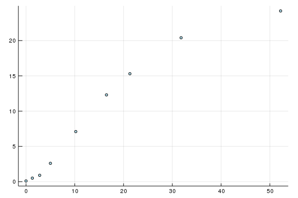

```julia
# Exemplo: https://www.medcalc.org/manual/nonlinearregression_example.php
dose = [0.0; 1.3; 2.8; 5.0; 10.2; 16.5; 21.3; 31.8; 52.2]
response = [0.1; 0.5; 0.9; 2.6; 7.1; 12.3; 15.3; 20.4; 24.2]
scatter(dose, response, ms=3, c=:lightblue, leg=false)
```

Vamos tentar usar o modelo $$ h_{\theta}(x) = \theta_4 + \frac{\theta_1 - \theta_4}{1 + \bigg(\dfrac{x}{\theta_3}\bigg)^{\theta_2}}. $$

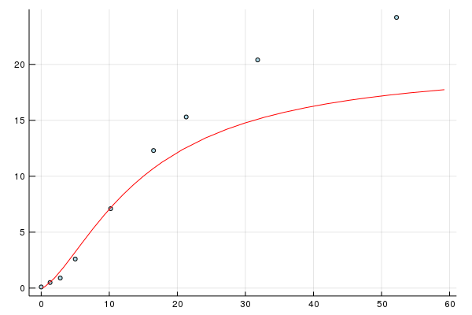

```julia
scatter(dose, response, ms=3, c=:lightblue, leg=false)
θ = [0.0; 1.5; 15.0; 20.0]
h(x) = if x == 0.0 θ[1] else θ[4] + (θ[1] - θ[4]) / (1 + (x / θ[3])^θ[2]) end
plot!(h, 0, 60, c=:red)
```

- Quadrados Mínimos Não-Lineares $$ L(\theta) = \frac{1}{2}\sum_{i = 1}^m \big(h_{\theta}(x^i) - y^i\big)^2. $$
- Esse problema é bem mais complicado de se resolver, e não temos uma expressão bonita;
- Podemos usar outros métodos de otimização;
- Vamos usar o método do gradiente com busca inexata.

```julia
using ForwardDiff

function gradiente(L, θ₀; η = 0.01, ϵ = 1e-4, max_iter = 10000)
    θ = copy(θ₀)
    ∇L(θ) = ForwardDiff.gradient(L, θ)
    ∇Lθ = ∇L(θ)
    iter = 0
    while !(norm(∇Lθ) <= ϵ || iter > max_iter)
        t = 1.0
        slope = -dot(∇Lθ, ∇Lθ)
        while !(L(θ - t * ∇Lθ) < L(θ) + 1e-2 * t * slope)
            t *= 0.5
            if t < 1e-8
                break
            end
        end
        θ -= t * ∇Lθ
        ∇Lθ = ∇L(θ)
        iter += 1
    end
    return θ, ∇Lθ, iter
end
```

```
gradiente (generic function with 1 method)
```

```julia
model(x, θ) = if x == 0.0 θ[1] else θ[4] + (θ[1] - θ[4]) / (1 + (x / θ[3])^θ[2]) end
m = length(dose)
L(θ) = 0.5 * sum((model(dose[i],θ) - response[i])^2 for i = 1:m)
θ, ∇Lθ, iter = gradiente(L, [0.5; 2.5; 20.0; 20.0])
```

```
([0.153653, 1.77186, 19.3485, 28.4469], [-4.04831e-6, 6.11134e-5, -5.47081e-5, -5.58296e-5], 2172)
```

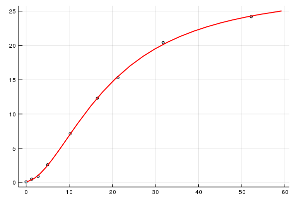

```julia
scatter(dose, response, ms=3, c=:lightblue, leg=false)
plot!(x -> model(x, θ), 0, 60, c=:red, lw=2)
```

# Regressão Logística

- Vamos considerar agora que $y^i \in \{0, 1\}$;
- Vamos usar o modelo $$ h_{\theta}(x) = \sigma(\theta^T\phi(x)) = \frac{1}{1 + e^{-\theta^T\phi(x)}}; $$
- $\phi(x) = (1,x_1,\dots,x_p)^T$, tradicionalmente;
- Num exemplo $x^i \in \mathbb{R}$, $$ h_{\theta}(x) = \frac{1}{1 + e^{-\theta_0 - \theta_1 x}}; $$
- A função de perda que podemos usar é $$ \ell(p, y) = -\ln\Big[p^y(1 - p)^{1-y}\Big] = -y\ln p - (1 - y)\ln(1 - p). $$

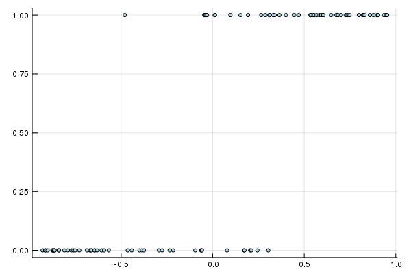

```julia
srand(0)
m = 100
x = sort(rand(m) * 2 - 1)
y = [x[i] + randn() * 0.25 < 0 ? 0 : 1 for i = 1:m]
scatter(x, y, ms=3, c=:lightblue, leg=false)
```

```julia
σ(t) = 1 / (1 + exp(-t))
L(θ) = -sum(y[i] * log(σ(θ[1] + θ[2] * x[i])) +
        (1 - y[i]) * log(1 - σ(θ[1] + θ[2] * x[i])) for i = 1:m)
θ, ∇Lθ, iter = gradiente(L, zeros(2))
```

```
([-0.0650913, 5.81695], [9.8137e-5, 5.37396e-6], 385)
```

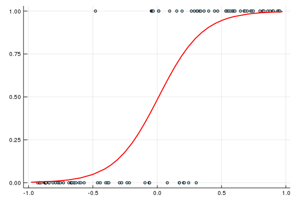

```julia
plot!(x -> σ(θ[1] + θ[2] * x), -1, 1, c=:red, lw=2)
```

- Na prática, como queremos classificar, arredondamos o modelo

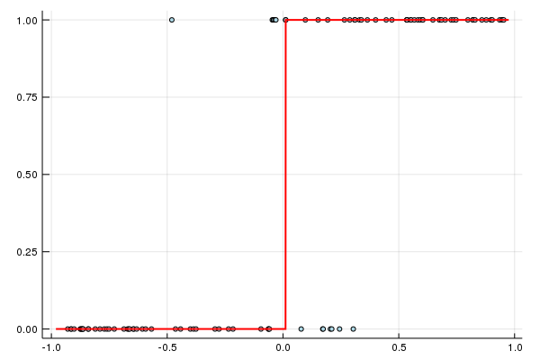

```julia
scatter(x, y, ms=3, c=:lightblue, leg=false)
plot!(x -> round(σ(θ[1] + θ[2] * x)), -1, 1, c=:red, lw=2)
```

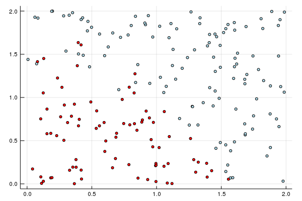

```julia
m = 200
x = rand(m,2) * 2
y = [x[i,1]^2 + x[i,2]^2 + randn() * 0.4 > 2 ? 1.0 : 0.0 for i = 1:m]
I = find(y .== 0)
scatter(x[I,1], x[I,2], c=:red, ms=3, leg=false)
I = find(y .== 1)
scatter!(x[I,1], x[I,2], c=:lightblue, ms=3)
```

```julia
ϕ(x) = [1.0; x[1]; x[2]]
L(θ) = -sum(y[i] * log(σ(dot(θ, ϕ(x[i,:])))) +
        (1 - y[i]) * log(1 - σ(dot(θ, ϕ(x[i,:])))) for i = 1:m)
θ, ∇Lθ, iter = gradiente(L, zeros(3))
```

```
([-13.1757, 7.44034, 7.13999], [9.569e-5, 3.8816e-6, 6.53784e-6], 1023)
```

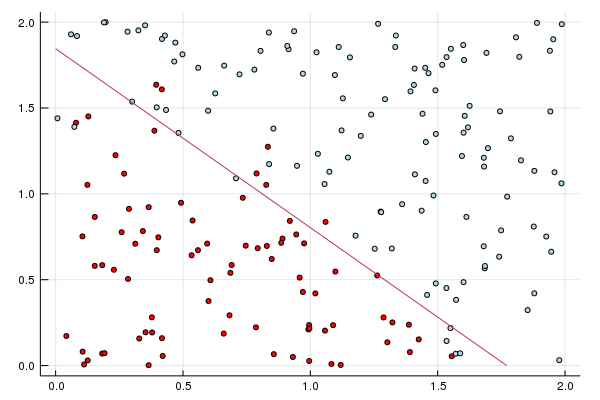

```julia
I = find(y .== 0)
scatter(x[I,1], x[I,2], c=:red, ms=3, leg=false)
I = find(y .== 1)
scatter!(x[I,1], x[I,2], c=:lightblue, ms=3)
contour!(linspace(0, 2, 100), linspace(0, 2, 100), (x, y) -> σ(dot(θ, ϕ([x; y]))), levels=[0.5])
```

```julia
ϕ(x) = [1.0; x[1]; x[2]; x[1]^2; x[1] * x[2]; x[2]^2]
L(θ) = -sum(y[i] == 0 ? log(1 - σ(dot(θ, ϕ(x[i,:])))) :
        log(σ(dot(θ, ϕ(x[i,:])))) for i = 1:m)
θ, ∇Lθ, iter = gradiente(L, zeros(6), max_iter = 1000)
```

```
([-9.86786, -8.31277, 5.91278, 9.31926, 2.19915, 0.88467], [0.160762, 0.152464, 0.0767858, 0.073301, 0.0788164, 0.198577], 1001)
```

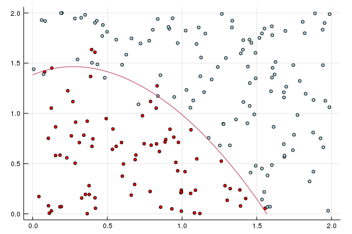

```julia
I = find(y .== 0)
scatter(x[I,1], x[I,2], c=:red, ms=3, leg=false)
I = find(y .== 1)
scatter!(x[I,1], x[I,2], c=:lightblue, ms=3)
contour!(linspace(0, 2, 100), linspace(0, 2, 100), (x, y) -> σ(dot(θ, ϕ([x; y]))), levels=[0.5])
```